**AML2019**

### Challenge 1

# House Pricing Prediction

*22<sup>th</sup> March 2019*

The first AML challenge for this year is adapted from the well-known '*Zillow's Home Value Prediction*' competition on Kaggle. In particular, given a dataset containing descriptions of homes on the US property market, your task is to make predictions on the selling price of as-yet unlisted properties. Developing a model which accurately fits the available training data while also generalising to unseen data-points is a multi-faceted challenge that involves a mixture of data exploration, pre-processing, model selection, and performance evaluation.

# Overview

Beyond simply producing a well-performing model for making predictions, in this challenge we would like you to start developing your skills as a machine learning scientist. In this regard, your notebook should be structured in such a way as to explore the five following tasks that are expected to be carried out whenever undertaking such a project. The description below each aspect should serve as a guide for your work, but you are strongly encouraged to also explore alternative options and directions. Thinking outside the box will always be rewarded in these challenges.

[reference from Kaggle](https://www.kaggle.com/mgmarques/houses-prices-complete-solution)

### 1. Data Exploration

The first broad component of your notebook should enable you to familiarise yourselves with the given data, an outline of which is given at the end of this challenge specification. Among others, this section should investigate:

- Data cleaning, e.g. treatment of categorial variables;
- Data visualisation;
- Computing descriptive statistics, e.g. correlation.
- etc.

```python
import numpy as np
import pandas as pd
import matplotlib.pyplot as plt

from sklearn.model_selection import train_test_split, cross_val_score, GridSearchCV
from sklearn import preprocessing
from sklearn.linear_model import Lasso, ElasticNet
from sklearn.ensemble import GradientBoostingRegressor, IsolationForest, AdaBoostRegressor
from sklearn import metrics
from sklearn.metrics import r2_score
import seaborn as sns
from sklearn.linear_model import HuberRegressor
from sklearn.metrics import mean_squared_error
```

```python
# Read the .csv file (might take a while)
train = pd.read_csv('Data/train.csv')
test = pd.read_csv('Data/test.csv')
train[:10]
```

|  | Id | MSSubClass | MSZoning | LotFrontage | LotArea | Street | Alley | LotShape | LandContour | Utilities | ... | PoolArea | PoolQC | Fence | MiscFeature | MiscVal | MoSold | YrSold | SaleType | SaleCondition | SalePrice |
| --- | --- | --- | --- | --- | --- | --- | --- | --- | --- | --- | --- | --- | --- | --- | --- | --- | --- | --- | --- | --- | --- |
| 0 | 1 | 60 | RL | 65.0 | 8450 | Pave | NaN | Reg | Lvl | AllPub | ... | 0 | NaN | NaN | NaN | 0 | 2 | 2008 | WD | Normal | 208500 |
| 1 | 2 | 20 | RL | 80.0 | 9600 | Pave | NaN | Reg | Lvl | AllPub | ... | 0 | NaN | NaN | NaN | 0 | 5 | 2007 | WD | Normal | 181500 |
| 2 | 3 | 60 | RL | 68.0 | 11250 | Pave | NaN | IR1 | Lvl | AllPub | ... | 0 | NaN | NaN | NaN | 0 | 9 | 2008 | WD | Normal | 223500 |
| 3 | 4 | 70 | RL | 60.0 | 9550 | Pave | NaN | IR1 | Lvl | AllPub | ... | 0 | NaN | NaN | NaN | 0 | 2 | 2006 | WD | Abnorml | 140000 |
| 4 | 5 | 60 | RL | 84.0 | 14260 | Pave | NaN | IR1 | Lvl | AllPub | ... | 0 | NaN | NaN | NaN | 0 | 12 | 2008 | WD | Normal | 250000 |
| 5 | 6 | 50 | RL | 85.0 | 14115 | Pave | NaN | IR1 | Lvl | AllPub | ... | 0 | NaN | MnPrv | Shed | 700 | 10 | 2009 | WD | Normal | 143000 |
| 6 | 7 | 20 | RL | 75.0 | 10084 | Pave | NaN | Reg | Lvl | AllPub | ... | 0 | NaN | NaN | NaN | 0 | 8 | 2007 | WD | Normal | 307000 |
| 7 | 8 | 60 | RL | NaN | 10382 | Pave | NaN | IR1 | Lvl | AllPub | ... | 0 | NaN | NaN | Shed | 350 | 11 | 2009 | WD | Normal | 200000 |
| 8 | 9 | 50 | RM | 51.0 | 6120 | Pave | NaN | Reg | Lvl | AllPub | ... | 0 | NaN | NaN | NaN | 0 | 4 | 2008 | WD | Abnorml | 129900 |
| 9 | 10 | 190 | RL | 50.0 | 7420 | Pave | NaN | Reg | Lvl | AllPub | ... | 0 | NaN | NaN | NaN | 0 | 1 | 2008 | WD | Normal | 118000 |

10 rows × 81 columns

**First explorations**

```python
print("number of columns ",len(list(train)),"\n")
print(list(train))
```

```
number of columns  81

['Id', 'MSSubClass', 'MSZoning', 'LotFrontage', 'LotArea', 'Street', 'Alley', 'LotShape', 'LandContour', 'Utilities', 'LotConfig', 'LandSlope', 'Neighborhood', 'Condition1', 'Condition2', 'BldgType', 'HouseStyle', 'OverallQual', 'OverallCond', 'YearBuilt', 'YearRemodAdd', 'RoofStyle', 'RoofMatl', 'E…
```

As we can see in the document that explains what contains column, the data should be cleaned. First of all, the categorial quality variables should be converted into numerical variables. Indeed, we can't use these column if they aren't numbers.  
**Data cleaning**

```python
def categorial_to_numeric(x, possibilities, rescaling=1):
    """:param x: an input data easily converted into a number. "Ex", "Po" for instance
        :param possibilities: the list of the different possibilities for x.
                                NOTE : the list should be sorted with the 'best' parameters at the end
        :return: the numeric equivalent, rescaled with respect to the rescaling ratio"""
    if x in possibilities:
        return (possibilities.index(x)+1)*rescaling
    else:
        raise Exception("x should belong to the list",x, possibilities)

def replace_column(df, column, possibilities, rescaling=1):
    """NOTE the previous function is for one input, this one should be applied to a whole column
        :param df: should not be the 'original' dataframe if you want to keep it unchanged
        :param column: a categorical column that needs to be changed to numeric values
        :param possibilities: the different possibile categories for the inputs
        :return: the dataframe with the variable column made numeric"""
    series = df[df[column].notna()][column]
    series = series.map(lambda x : categorial_to_numeric(x, possibilities, rescaling))
    df[column] = series
    return  df

def remove_unrelevant(df):
    nb_r,_ = df.shape
    nb_non_na = df[df.notnull()==True].count()
    to_drop = (nb_non_na < 0.2*nb_r)
    to_drop_tracked = []
    for column in to_drop.index:
        if to_drop.loc[column]==True:
            to_drop_tracked.append(column)
            df = df.drop(column,axis=1)
    return df,to_drop_tracked

def sort_categories(df, column, possibilities_dict):
    """Sorts the list 'possibilities' to have an increasing salePrice with respect to the possible values of the variable 'column'"""
    possibilities = list(df.groupby(column).mean().sort_values('SalePrice').index)
    for x in possibilities_dict[column]:
        if not(x in possibilities):
            possibilities.insert(0,x)
    return possibilities

def test_str_column(series):
    """trick to check if a column is of type str
    NOTE : SHOULD BE APPLIED AFTER APPLYING FILLNA(0) ON THE DATAFRAME"""
    first_input = series.loc[0]
    if type(first_input) == str:
        return True
    elif first_input == 0:
        i = 1
        data = series.loc[i]
        while data == 0: # necessary because we used "fillna(0)" before calling this function
            i+=1
            data = series.loc[i]
        return (type(data) == str)
    else:
        return False

def clean(df_source, possibilities_dict):
    """the function used to treat the categorical variables. We return a value between 0 and 1."""

    df_keep_some_na = df_source.copy()
    df_with0 = df_source.copy()
    df_with0.fillna(0, inplace=True)

    #First, remove columns when they don't have enough non-null inputs
    df_keep_some_na, dropped_columns = remove_unrelevant(df_keep_some_na)

    new_possibilities_dict = {} #to keep track of a new sorting of the possibilities in order to have an increasing salePrice
    updated_columns_list = []

    for column in list(df_keep_some_na):
        if test_str_column(df_with0[column]):
            if 'NA' in possibilities_dict[column]: #NA is necessarily in first position
                possibilities_dict[column][0] = 0
                df_keep_some_na[column].fillna(0,inplace=True)

            possibilities = sort_categories(df_keep_some_na,column,possibilities_dict)
            new_possibilities_dict[column] = possibilities

            replace_column(df_keep_some_na, column, possibilities, rescaling = 1/len(possibilities))
            updated_columns_list.append(column)


#     print("we updated ",len(updated_columns_list)," columns")
    return df_keep_some_na,new_possibilities_dict, dropped_columns

possibilities_dict = {
    'MSZoning' : ['A','C (all)','FV','I','RH','RL','RP','RM'],
    'Street' : ['Grvl','Pave'],
    'Alley' : ['NA','Grvl','Pave'],
    'LotShape' : ['Reg','IR1','IR2','IR3'],
    'LandContour' : ['Lvl','Bnk','HLS','Low'],
    'Utilities' : ['AllPub','NoSewr','NoSeWa','ELO'],
    'LotConfig' : ['Inside','Corner','CulDSac','FR2','FR3'],
    'LandSlope' : ['Gtl','Mod','Sev'],
    'Neighborhood' : ['Blmngtn','BlueSte','BrDale','BrkSide','ClearCr','Crawfor','Edwards','Gilbert','IDOTRR','MeadowV','Mitchel','Names','NoRidge','NPkVill','NWAmes','OldTown','SWISU','Sawyer','SawyerW','Somerst','StoneBr','Timber','Veenker'],
    'Condition1' : ['Artery','Feed','Norm','RRNn','RRAn','PosN','PosA','RRNe','RRAe'],
    'Condition2' : ['Artery','Feed','Norm','RRNn','RRAn','PosN','PosA','RRNe','RRAe'],
    'BldgType' : ['1Fam','2FmCon','Duplx','TwnhsE','TwnhsI'],
    'HouseStyle' : ['1Story','1.5Fin','1.5Unf','2Story','2.5Fin','2.5Unf','SFoyer','SLvl'],
    'RoofStyle' : ['Flat','able','Gambrel','Hip','Mansard','Shed'],
    'RoofMatl' : ['ClyTile','CompShg','Membran','Metal','Roll','Tar&Grv','WdShake','WdShngl'],
    'Exterior1st' : ['AsbShng','AsphShn','BrkComm','BrkFace','CBlock','CemntBd','HdBoard','ImStucc','MetalSd','Other','Plywood','PreCast','Stone','VinylSd','Wd Sdng','WdShing'],
    'Exterior2nd' : ['AsbShng','AsphShn','BrkComm','BrkFace','CBlock','CemntBd','HdBoard','ImStucc','MetalSd','Other','Plywood','PreCast','Stone','VinylSd','Wd Sdng','WdShing'],
    'MasVnrType' : ['BrkCmn','BrkFace','CBlock','None','Stone'],
    'ExterQual' : ['Po','Fa','TA','Gd','Ex'],
    'ExterCond' : ['Po','Fa','TA','Gd','Ex'],
    'Foundation' : ['BrkTil','CBlock','Pconc','Slab','Stone','Wood'],
    'BsmtQual' : ['NA','Po','Fa','TA','Gd','Ex'],
    'BsmtCond' : ['NA','Po','Fa','TA','Gd','Ex'],
    'BsmtExposure' : ['NA','No','Mn','Av','Gd'],
    'BsmtFinType1' : ['NA','Unf','LwQ','Rec','BLQ','ALQ','GLQ'],
    'BsmtFinType2': ['NA','Unf','LwQ','Rec','BLQ','ALQ','GLQ'],
    'Heating' : ['Floor','GasA','GasW','Grav','OthW','Wall'],
    'HeatingQC' : ['Po','Fa','TA','Gd','Ex'],
    'CentralAir' : ['N','Y'],
    'Electrical' : ['SBrkr','FuseA','FuseF','FuseP','Mix'],
    'KitchenQual' : ['Po','Fa','TA','Gd','Ex'],
    'Functional' : ['Typ','Min1','Min2','Mod','Maj1','Maj2','Sev','Sal'],
    'FireplaceQu' : ['NA','Po','Fa','TA','Gd','Ex'],
    'GarageType' : ['NA','2Types','Attchd','Basement','BuiltIn','CarPort','Detchd'],
    'GarageFinish' : ['NA','Unf','RFn','Fin'],
    'GarageQual' : ['NA','Po','Fa','TA','Gd','Ex'],
    'GarageCond' : ['NA','Po','Fa','TA','Gd','Ex'],
    'PavedDrive' : ['Y','P','N'],
    'PoolQC' : ['NA','Fa','TA','Gd','Ex'],
    'Fence' : ['MnWw','GdWo','MnPrv','GdPrv'],
    'MiscFeature' : ['NA','Elev','Gar2','Othr','Shed','TenC'],
    'SaleType' : ['WD','CWD','VWD','New','COD','Con','ConLw','CondLI','ConLD','Oth'],
    'SaleCondition' : ['Normal','Abnorml','AdjLand','Alloca','Family','Partial']
}

train_cleaned, possibilities_tracked, dropped_columns = clean(train, possibilities_dict)
train_cleaned.to_csv("Data/train_cleaned.csv")
train_cleaned.head(10)
```

|  | Id | MSSubClass | MSZoning | LotFrontage | LotArea | Street | LotShape | LandContour | Utilities | LotConfig | ... | EnclosedPorch | 3SsnPorch | ScreenPorch | PoolArea | MiscVal | MoSold | YrSold | SaleType | SaleCondition | SalePrice |
| --- | --- | --- | --- | --- | --- | --- | --- | --- | --- | --- | --- | --- | --- | --- | --- | --- | --- | --- | --- | --- | --- |
| 0 | 1 | 60 | 0.875 | 65.0 | 8450 | 1.0 | 0.25 | 0.5 | 1.0 | 0.6 | ... | 0 | 0 | 0 | 0 | 0 | 2 | 2008 | 0.636364 | 0.833333 | 208500 |
| 1 | 2 | 20 | 0.875 | 80.0 | 9600 | 1.0 | 0.25 | 0.5 | 1.0 | 0.4 | ... | 0 | 0 | 0 | 0 | 0 | 5 | 2007 | 0.636364 | 0.833333 | 181500 |
| 2 | 3 | 60 | 0.875 | 68.0 | 11250 | 1.0 | 0.50 | 0.5 | 1.0 | 0.6 | ... | 0 | 0 | 0 | 0 | 0 | 9 | 2008 | 0.636364 | 0.833333 | 223500 |
| 3 | 4 | 70 | 0.875 | 60.0 | 9550 | 1.0 | 0.50 | 0.5 | 1.0 | 0.8 | ... | 272 | 0 | 0 | 0 | 0 | 2 | 2006 | 0.636364 | 0.333333 | 140000 |
| 4 | 5 | 60 | 0.875 | 84.0 | 14260 | 1.0 | 0.50 | 0.5 | 1.0 | 0.4 | ... | 0 | 0 | 0 | 0 | 0 | 12 | 2008 | 0.636364 | 0.833333 | 250000 |
| 5 | 6 | 50 | 0.875 | 85.0 | 14115 | 1.0 | 0.50 | 0.5 | 1.0 | 0.6 | ... | 0 | 320 | 0 | 0 | 700 | 10 | 2009 | 0.636364 | 0.833333 | 143000 |
| 6 | 7 | 20 | 0.875 | 75.0 | 10084 | 1.0 | 0.25 | 0.5 | 1.0 | 0.6 | ... | 0 | 0 | 0 | 0 | 0 | 8 | 2007 | 0.636364 | 0.833333 | 307000 |
| 7 | 8 | 60 | 0.875 | NaN | 10382 | 1.0 | 0.50 | 0.5 | 1.0 | 0.8 | ... | 228 | 0 | 0 | 0 | 350 | 11 | 2009 | 0.636364 | 0.833333 | 200000 |
| 8 | 9 | 50 | 0.625 | 51.0 | 6120 | 1.0 | 0.25 | 0.5 | 1.0 | 0.6 | ... | 205 | 0 | 0 | 0 | 0 | 4 | 2008 | 0.636364 | 0.333333 | 129900 |
| 9 | 10 | 190 | 0.875 | 50.0 | 7420 | 1.0 | 0.25 | 0.5 | 1.0 | 0.8 | ... | 0 | 0 | 0 | 0 | 0 | 1 | 2008 | 0.636364 | 0.833333 | 118000 |

10 rows × 77 columns

```python
def remove_unrelevant_test(df_src, dropped_columns):
    df = df_src.copy()
    for column in dropped_columns:
        df = df.drop(column, axis=1)
    return df

def clean_test(df_source, possibilities_dict):
    """the function used to treat the categorical variables of the test data. We return a value between 0 and 1.
    :param possibilities_dict: we should use the 'newpossibilities_dict' returned by the previous function"""

    df_keep_some_na = df_source.copy()
    df_with0 = df_source
    df_with0.fillna(0, inplace=True)

    #First, remove columns identified as unrelevant during training
    df_keep_some_na =  remove_unrelevant_test(df_keep_some_na, dropped_columns)

    for column in list(df_keep_some_na):
        if test_str_column(df_with0[column]):
            if column in possibilities_dict.keys():

                values = list(df_keep_some_na[column].unique())
                possibilities = possibilities_dict[column]
                if 0 in possibilities:
                    df_keep_some_na[column].fillna(0,inplace=True)

                for x in values:
                    if not(x in possibilities):
                        possibilities.insert(0,x)
                replace_column(df_keep_some_na, column, possibilities, rescaling = 1/len(possibilities))

    return df_keep_some_na


test_cleaned = clean_test(test, possibilities_tracked)
test_cleaned.to_csv("Data/test_cleaned.csv")
test_cleaned.head(10)
```

|  | Id | MSSubClass | MSZoning | LotFrontage | LotArea | Street | LotShape | LandContour | Utilities | LotConfig | ... | OpenPorchSF | EnclosedPorch | 3SsnPorch | ScreenPorch | PoolArea | MiscVal | MoSold | YrSold | SaleType | SaleCondition |
| --- | --- | --- | --- | --- | --- | --- | --- | --- | --- | --- | --- | --- | --- | --- | --- | --- | --- | --- | --- | --- | --- |
| 0 | 1201 | 20 | 0.875 | 71.0 | 9353 | 1.0 | 0.25 | 0.5 | 1.0 | 0.6 | ... | 0 | 0 | 0 | 0 | 0 | 0 | 7 | 2006 | 0.272727 | 0.333333 |
| 1 | 1202 | 60 | 0.875 | 80.0 | 10400 | 1.0 | 0.25 | 0.5 | 1.0 | 0.8 | ... | 36 | 0 | 0 | 0 | 0 | 0 | 3 | 2009 | 0.636364 | 0.833333 |
| 2 | 1203 | 50 | 0.625 | 50.0 | 6000 | 1.0 | 0.25 | 0.5 | 1.0 | 0.8 | ... | 0 | 208 | 0 | 0 | 0 | 0 | 5 | 2009 | 0.636364 | 0.833333 |
| 3 | 1204 | 20 | 0.875 | 75.0 | 9750 | 1.0 | 0.25 | 0.5 | 1.0 | 0.6 | ... | 234 | 0 | 0 | 0 | 0 | 0 | 10 | 2009 | 0.636364 | 0.833333 |
| 4 | 1205 | 20 | 0.875 | 78.0 | 10140 | 1.0 | 0.25 | 0.5 | 1.0 | 0.6 | ... | 88 | 0 | 0 | 0 | 0 | 0 | 7 | 2006 | 0.636364 | 0.833333 |
| 5 | 1206 | 20 | 0.875 | 90.0 | 14684 | 1.0 | 0.50 | 0.5 | 1.0 | 1.0 | ... | 70 | 0 | 0 | 0 | 0 | 0 | 6 | 2009 | 0.636364 | 0.833333 |
| 6 | 1207 | 20 | 0.750 | NaN | 8900 | 1.0 | 0.25 | 0.5 | 1.0 | 0.6 | ... | 42 | 0 | 0 | 0 | 0 | 0 | 11 | 2006 | 0.636364 | 0.833333 |
| 7 | 1208 | 20 | 0.875 | 70.0 | 9135 | 1.0 | 0.25 | 0.5 | 1.0 | 0.6 | ... | 23 | 0 | 0 | 0 | 0 | 0 | 5 | 2006 | 0.636364 | 0.833333 |
| 8 | 1209 | 20 | 0.875 | 70.0 | 7763 | 1.0 | 0.25 | 0.5 | 1.0 | 0.6 | ... | 0 | 0 | 0 | 0 | 0 | 0 | 10 | 2008 | 0.636364 | 0.833333 |
| 9 | 1210 | 20 | 0.875 | 85.0 | 10182 | 1.0 | 0.50 | 0.5 | 1.0 | 1.0 | ... | 50 | 0 | 0 | 0 | 0 | 0 | 5 | 2006 | 1.000000 | 1.000000 |

10 rows × 76 columns

**Data Visualization**

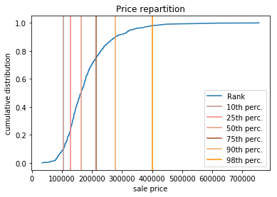

```python
fig, ax = plt.subplots()
house_DF = train.copy()
df = house_DF.sort_values(by='SalePrice')
df = df.reset_index()
df['Rank']=df.index/df.index.max()


# Plot the cumulative distribution
df.plot(ax=ax, y= 'Rank', x= 'SalePrice') #j'ai modifié, la cdf décrit "y% des maisons se sont vendues à moins de x€ ?"

# Calculate and plot the 5 important percentiles
colors=['rosybrown','lightcoral','darksalmon', 'sienna','sandybrown' , 'darkorange','darkolivegreen']
for i, quantile in enumerate([.1, 0.25, .5, .75, .9, .98]):
    ax.axvline(df.SalePrice.quantile(quantile), label='%.0fth perc.' % (quantile*100), color=colors[i])


ax.set_title('Price repartition')
ax.set_xlabel('sale price')
ax.set_ylabel('cumulative distribution')
ax.legend()
plt.show()
```

As we can see, the prices density is sharp (most prices are relatively near from the median). Furthermore, the top-10% of the prices are are widely spread and may imply a bias on our model, especially since they are likely to be outliers (more likely to be overestimated...). In order to have relevant outputs with these, we may have to treat them separately

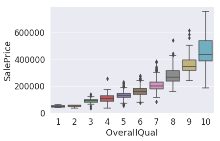

```python
import seaborn as sns
sns.set(style="ticks", color_codes=True, font_scale=1.5)
color = sns.color_palette()
sns.set_style('darkgrid')
fig1 =  sns.boxplot(x='OverallQual', y='SalePrice', data=train[['SalePrice', 'OverallQual']])
```

**Descriptive statistics**

```python
statistical_description = train_cleaned.describe().transpose()
statistical_description['CorrelationWithSalePrice'] = train_cleaned.corr()['SalePrice']
statistical_description.sort_values('CorrelationWithSalePrice',ascending = False, inplace=True)
statistical_description.head(20)
```

|  | count | mean | std | min | 25% | 50% | 75% | max | CorrelationWithSalePrice |
| --- | --- | --- | --- | --- | --- | --- | --- | --- | --- |
| SalePrice | 1200.0 | 181414.628333 | 81070.908544 | 34900.000000 | 129900.000000 | 163700.000000 | 214000.000000 | 755000.0 | 1.000000 |
| OverallQual | 1200.0 | 6.105000 | 1.383439 | 1.000000 | 5.000000 | 6.000000 | 7.000000 | 10.0 | 0.789142 |
| GrLivArea | 1200.0 | 1508.977500 | 517.380330 | 334.000000 | 1125.750000 | 1456.000000 | 1764.500000 | 4676.0 | 0.740379 |
| Neighborhood | 1200.0 | 0.554475 | 0.239694 | 0.111111 | 0.333333 | 0.555556 | 0.703704 | 1.0 | 0.694722 |
| ExterQual | 1200.0 | 0.679000 | 0.114761 | 0.400000 | 0.600000 | 0.600000 | 0.800000 | 1.0 | 0.679614 |
| KitchenQual | 1200.0 | 0.701500 | 0.133214 | 0.400000 | 0.600000 | 0.600000 | 0.800000 | 1.0 | 0.656790 |
| TotalBsmtSF | 1200.0 | 1054.700000 | 419.996306 | 0.000000 | 796.000000 | 1002.500000 | 1298.250000 | 3206.0 | 0.641917 |
| GarageCars | 1200.0 | 1.763333 | 0.743494 | 0.000000 | 1.000000 | 2.000000 | 2.000000 | 4.0 | 0.640961 |
| BsmtQual | 1200.0 | 0.753056 | 0.132132 | 0.333333 | 0.666667 | 0.833333 | 0.833333 | 1.0 | 0.623330 |
| GarageArea | 1200.0 | 472.604167 | 212.722444 | 0.000000 | 334.500000 | 478.000000 | 576.000000 | 1390.0 | 0.623329 |
| 1stFlrSF | 1200.0 | 1157.430833 | 375.238607 | 334.000000 | 882.000000 | 1087.000000 | 1390.250000 | 3228.0 | 0.618556 |
| FullBath | 1200.0 | 1.560833 | 0.552165 | 0.000000 | 1.000000 | 2.000000 | 2.000000 | 3.0 | 0.571867 |
| TotRmsAbvGrd | 1200.0 | 6.494167 | 1.614664 | 2.000000 | 5.000000 | 6.000000 | 7.000000 | 14.0 | 0.559435 |
| GarageFinish | 1200.0 | 0.679375 | 0.224541 | 0.250000 | 0.500000 | 0.750000 | 0.750000 | 1.0 | 0.542407 |
| YearBuilt | 1200.0 | 1971.350833 | 30.048408 | 1875.000000 | 1954.000000 | 1973.000000 | 2000.000000 | 2010.0 | 0.523194 |
| FireplaceQu | 1200.0 | 0.545972 | 0.226157 | 0.166667 | 0.333333 | 0.500000 | 0.833333 | 1.0 | 0.522193 |
| YearRemodAdd | 1200.0 | 1984.987500 | 20.527221 | 1950.000000 | 1967.000000 | 1994.000000 | 2004.000000 | 2010.0 | 0.509916 |
| Foundation | 1200.0 | 0.744286 | 0.235527 | 0.285714 | 0.571429 | 0.571429 | 1.000000 | 1.0 | 0.504012 |
| GarageYrBlt | 1133.0 | 1978.368932 | 24.812865 | 1900.000000 | 1961.000000 | 1980.000000 | 2002.000000 | 2010.0 | 0.489794 |
| GarageType | 1200.0 | 0.742292 | 0.210848 | 0.250000 | 0.500000 | 0.875000 | 0.875000 | 1.0 | 0.487559 |

**Comment :**  
This table describe attributes of houses which are numeric variable, it is ranked regarding correlation with sale price. For us the column with the highest correlation are the one that are going to be the more usefull.  
It is not surprise that overall quality has the highest correlation with SalePrice among the numeric variables (0.79). It rates the overall material and finish of the house on a scale from 1 (very poor) to 10 (very excellent). Indeed, an house can't be saled for a high price if this quality is poor...  
We can notice that garage area and garage cars are well ranked and in our opinion it is quite suprising. We will try to deal with that : We don't buy an expensive house for the quality of its garage...  
In addition, we can see that the mean of the PoolArea is only 1.9, which means that only a few houses with a pool have been sold. As we can see below, there has actually been only 4 of them, and the house with a 'fair' pool has costed more than the one with a 'good' pool. There's no problem with that, but our design will probabli consider that a 'fair' pool is worth more than a good one. Hence, it's important that **we should weight each piece of information with the number of non-null inputs.**  
All in all, the top ten attributes are likely to be among the most important when trying to predict the sale price.

```python
train[train.PoolQC.notnull()][['PoolQC','PoolArea','SalePrice']]
```

|  | PoolQC | PoolArea | SalePrice |
| --- | --- | --- | --- |
| 197 | Ex | 512 | 235000 |
| 810 | Fa | 648 | 181000 |
| 1170 | Gd | 576 | 171000 |
| 1182 | Ex | 555 | 745000 |

**Data visualization bis**

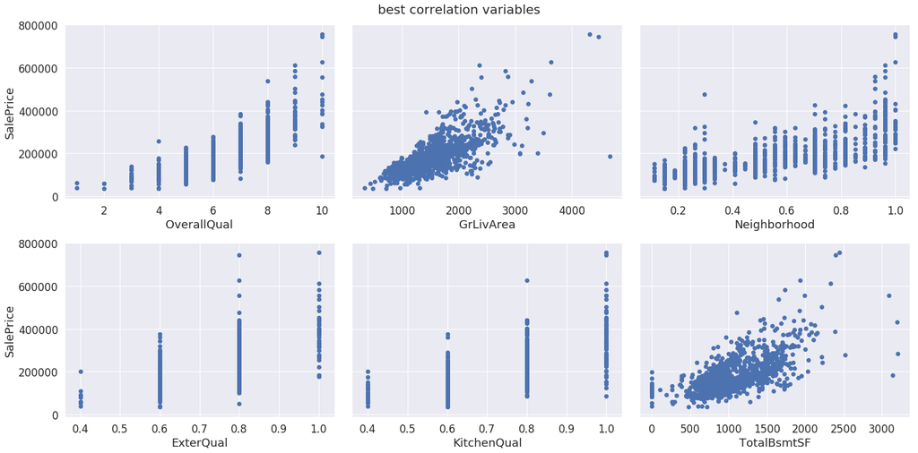

```python
data = train_cleaned.copy()

NB_ROWS=2
NB_COLUMNS=3
to_be_plotted = list(statistical_description.index)[1:NB_ROWS*NB_COLUMNS+1]

fig, axes = plt.subplots(nrows=NB_ROWS, ncols=NB_COLUMNS, constrained_layout=True, sharey = True)
fig.suptitle("best correlation variables", fontsize = 20)
fig.set_size_inches(20,10)

for i in range(NB_ROWS):
    for j in range(NB_COLUMNS):
        if j==0:
            axes[i][j].set_ylabel('SalePrice')

        k=NB_COLUMNS*i+j

        variable = to_be_plotted[k]

        axes[i][j].scatter(data[variable],data.SalePrice)
        axes[i][j].set_xlabel(variable)

plt.show()
```

The plot of variables that can take only few values (especially OverallQual) is not very relevant. This is why we should plot the mean price for some value of the variable to have a better visualisation.

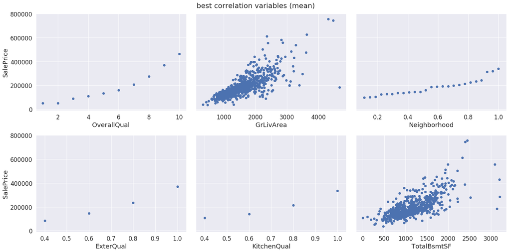

```python
data = train_cleaned.copy()
NB_ROWS=2
NB_COLUMNS=3
to_be_plotted = list(statistical_description.index)[1:NB_ROWS*NB_COLUMNS+1]


fig, axes = plt.subplots(nrows=NB_ROWS, ncols=NB_COLUMNS, constrained_layout = True, sharey = True)
fig.suptitle("best correlation variables (mean)", fontsize = 20)
fig.set_size_inches(20,10)

for i in range(NB_ROWS):
    for j in range(NB_COLUMNS):
        if j==0:
            axes[i][j].set_ylabel('SalePrice')

        k=NB_COLUMNS*i+j

        variable = to_be_plotted[k]

        categorical_mean = data.groupby(variable).mean()
        axes[i][j].scatter(categorical_mean.index,categorical_mean['SalePrice'])
        axes[i][j].set_xlabel(variable)

plt.show()
```

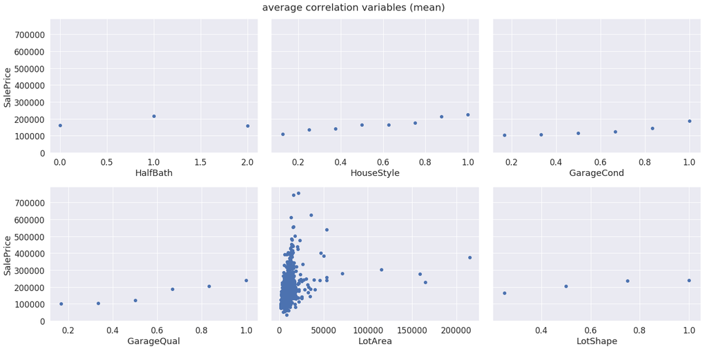

```python
data = train_cleaned.copy()
NB_ROWS=2
NB_COLUMNS=3
to_be_plotted = list(statistical_description.index)[35:NB_ROWS*NB_COLUMNS+35]


fig, axes = plt.subplots(nrows=NB_ROWS, ncols=NB_COLUMNS, constrained_layout = True, sharey = True)
fig.suptitle("average correlation variables (mean)", fontsize = 20)
fig.set_size_inches(20,10)

for i in range(NB_ROWS):
    for j in range(NB_COLUMNS):
        if j==0:
            axes[i][j].set_ylabel('SalePrice')

        k=NB_COLUMNS*i+j

        variable = to_be_plotted[k]

        categorical_mean = data.groupby(variable).mean()
        axes[i][j].scatter(categorical_mean.index,categorical_mean['SalePrice'])
        axes[i][j].set_xlabel(variable)

plt.show()
```

```
note that we do not print the mean this time because the data is spread widely (low correlation)
```

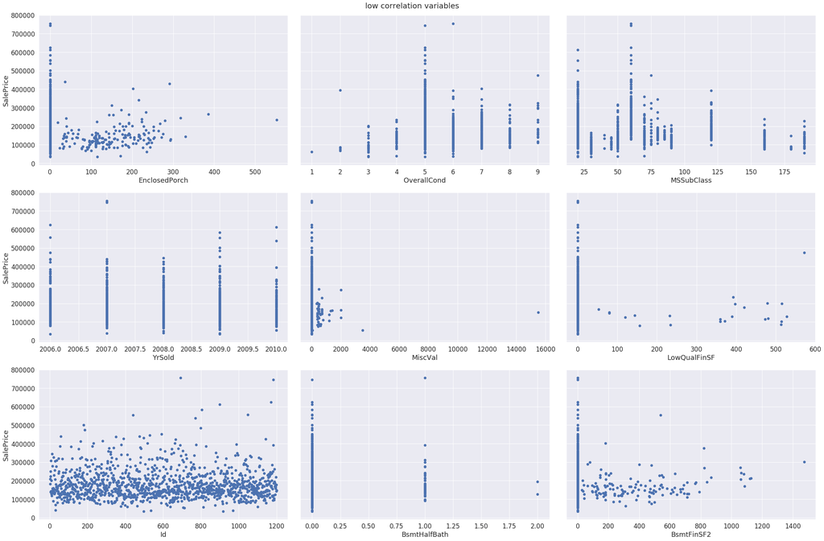

```python
data = train_cleaned.copy()

NB_ROWS=3
NB_COLUMNS=3
to_be_plotted = list(statistical_description.sort_values('CorrelationWithSalePrice').index)[1:NB_ROWS*NB_COLUMNS+1]
print("note that we do not print the mean this time because the data is spread widely (low correlation)" )
fig, axes = plt.subplots(nrows=NB_ROWS, ncols=NB_COLUMNS, constrained_layout= True, sharey = True)
fig.suptitle("low correlation variables", fontsize = 20)
fig.set_size_inches(30,20)

for i in range(NB_ROWS):
    for j in range(NB_COLUMNS):
        if j==0:
            axes[i][j].set_ylabel('SalePrice')

        k=NB_COLUMNS*i+j

        variable = to_be_plotted[k]

        axes[i][j].scatter(data[variable],data.SalePrice)
        axes[i][j].set_xlabel(variable)


# fig.tight_layout()
plt.show()
```

'MSZoning' : ['A','C','FV','I','RH','RL','RP','RM']  
For this column, the previous cleaning processus is not very efficient. Moreover, for some column, for example the one with Ex, gd etc. The difference between a fair kitchen an good kitchen can be a bit tricky. There is no fixed rule (at least we don"t know about them) so assigning a coefficient to each is hard. For us it would be clever to assign a high 'grade' to Ex and put less difference between fair, typical and good than between Ex and the other.  
It is then hard to define this difference. That is the goal of the following: we randomly assign coefficient to the different string and keep only assignment that have the highest correlation with sale price.

```python
from sklearn.model_selection import ParameterGrid
from sklearn.model_selection import ParameterSampler
from scipy.stats import uniform

train = pd.read_csv('Data/train.csv')

# The goal of this function is to find the value which permits to reach the highest correlation with sale price.
def improve_corr (dico,param,n_iter=500):
    """:input dico: a dictionnary containing all possible string values of a given column
        :input param: string name of the column to be modified (string to numerical value)
        :input n_iter: Number of different random combination that will be tried: for each iter we randmly chose each value among 0 and 10 for each string
        :return parameter combination between 0 and 10 that gave the biggest correlation with sales price among the one that were tried
    """


    hyperparameters = {}
    for item in dico:
        hyperparameters[item] =  uniform(0.,10.)
    parameter_grid = list(ParameterSampler(hyperparameters,n_iter=n_iter))
    parameter_combination_top=[]
    score_top=0
    df_source = train
    for parameter_combination in parameter_grid:
        df = df_source.copy()
        df[param] = [parameter_combination[str(item)] for item in df[param]]
        score=df.corr()['SalePrice'][param]
        if score>score_top:
            score_top=score
            parameter_combination_top=parameter_combination

    return parameter_combination_top,score_top
```

```python
train_cleaned2 = train.copy()
test_cleaned2 = test.copy()

for column in possibilities_dict: #possibilities dict was defined when cleaning the other way
    possibilities = list(train[column].unique())
    possibilities2 = list(test[column].unique())
    for x in possibilities:
        if not(x in possibilities_dict[column]):
            possibilities_dict[column].insert(0,str(x))
    for x in possibilities2:
        if not(x in possibilities_dict[column]):
            possibilities_dict[column].insert(0,str(x))
    dico={}
    for elem in possibilities_dict[column]:
        dico[elem]=0
    parameter_combination_top,score_top = improve_corr(dico,column,n_iter=100)

    train_cleaned2[column] = [parameter_combination_top[str(item)] for item in train_cleaned2[column]]
    test_cleaned2[column] = [parameter_combination_top[str(item)] for item in test_cleaned2[column]]
#     print("The column named ",column," has been changed into numerical value ")

train_cleaned2.fillna(0, inplace=True)  # We've chosen to fill na value by a 0
test_cleaned2.fillna(0, inplace=True)  # We've chosen to fill na value by a 0

train_cleaned2.to_csv("Data/train_cleaned2.csv")
test_cleaned2.to_csv("Data/test_cleaned2.csv")
del train_cleaned2
del test_cleaned2
```

### 2. Data Pre-processing

The previous step should give you a better understanding of which pre-processing is required for the data. This may include:

- Normalising and standardising the given data;
- Removing outliers;
- Carrying out feature selection, possibly using metrics derived from information theory;
- Handling missing information in the dataset;
- Augmenting the dataset with external information;
- Combining existing features.

**Removing outliers**

```
number of outliers :  60
```

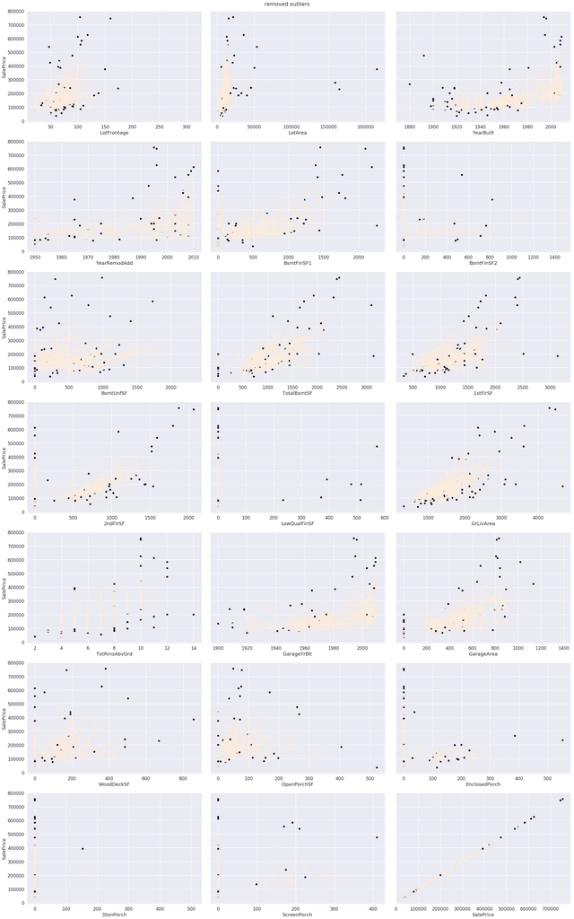

```python
data = train_cleaned.copy()
data_with0 = train_cleaned.copy()
to_be_plotted = ['LotFrontage','LotArea','YearBuilt','YearRemodAdd','BsmtFinSF1','BsmtFinSF2','BsmtUnfSF','TotalBsmtSF','1stFlrSF','2ndFlrSF','LowQualFinSF','GrLivArea','TotRmsAbvGrd','GarageYrBlt','GarageArea','WoodDeckSF','OpenPorchSF','EnclosedPorch','3SsnPorch','ScreenPorch','SalePrice']

NB_PLOTS = len(to_be_plotted)
clf = IsolationForest(contamination=0.05)
data_with0.fillna(0,inplace=True)
clf.fit(data_with0)
pred_outlier = clf.predict(data_with0)

print("number of outliers : ",len(pred_outlier[pred_outlier==-1]))

nb_rows = NB_PLOTS//3
fig, axes = plt.subplots(nrows = nb_rows, ncols = 3, constrained_layout= True, sharey = True)
fig.suptitle("removed outliers", fontsize = 20)
fig.set_size_inches(30,nb_rows*7)

for i in range(nb_rows):
    for j in range(3):
        if j==0:
            axes[i][j].set_ylabel('SalePrice')

        k=3*i+j
        variable = to_be_plotted[k]
        axes[i][j].scatter(data[variable], data.SalePrice, c=pred_outlier)
        axes[i][j].set_xlabel(variable)
plt.show()
```

```python
###then delete the outliers
data["Outlier"] = pred_outlier
data = data.query('Outlier==1')
data = data.drop('Outlier', axis=1)


data2 = pd.read_csv('Data/train_cleaned2.csv')
data2["Outlier"] = pred_outlier
data2 = data2.query('Outlier==1')
data2 = data2.drop('Outlier', axis=1)

data.to_csv("Data/train_cleaned_outliersremoved.csv")
data2.to_csv("Data/train_cleaned2_outliersremoved.csv")
```

**feature selection**

**PCA**  
By talking with some of the italian students we heard speaking of PCA. It should be efficient so we choose to interest ouselves about it.

```python
from sklearn.preprocessing import StandardScaler
from sklearn.decomposition import PCA

train_PCA = pd.read_csv('Data/train_cleaned2.csv')

del train_PCA['SalePrice']

scaler = StandardScaler()
scaler.fit(train_PCA)
t_train = scaler.transform(train_PCA)

pca_hp = PCA(30)
train_PCA = pca_hp.fit_transform(t_train)
```

**Keep only items with a high correlation**  
We've tried to keep only column with a good correlation with SalePrice.

```python
train_selected= pd.read_csv('Data/train_cleaned2.csv')

corr = train_selected.corr()['SalePrice'] # Compute the correlation with the sale price

i=0
for x in corr:
    if (x <= 0.3 and x >=0) or (x >= -0.3 and x<=0): #Garder que les colomnes avec une correlation dans -0.3;0.3
        del train_selected[corr.index[i]]
    i+=1
```

We've tried to train some models on these dataset and error on test data were higher than without the selection. You can see the test in annex (we did it using random Forest). That's why we choose not to use this trick either in the following.

**Combining existing feature**  
We didn't find the time to implement the following idea and see the influence on results. We choose to spend more time on the model selection and optimization.

```python
# multiply garage area by number of car:

#Total Basement Area Vs 1st Flor Area:The multiplacation is better than total basement correlation

# There are four type of bathroom ? add these column (full bathroom = 1 half bathroom(eg. toilet)=0.5...)
```

### 3. Model Selection

Perhaps the most important segment of this challenge involves the selection of a model that can successfully handle the given data and yield sensible predictions. Instead of focusing exclusively on your final chosen model, it is also important to share your thought process in this notebook by additionally describing alternative candidate models. There is a wealth of models to choose from, such as *decision trees*, *random forests*, *(Bayesian) neural networks*, *Gaussian processes*, *LASSO regression*, and so on. There are several factors which may influence your decision:

- What is the model's complexity?
- Is the model interpretable?
- Is the model capable of handling different data-types?
- Does the model return uncertainty estimates along with predictions?

An in-depth evaluation of competing models in view of this and other criteria will elevate the quality of your submission and earn you a higher grade.

**Function to evaluate a model on the test**  
As stated at the end the score is determined using the root mean squared error between the logarithm of the predicted value and the logarithm of the observed sales price

```python
def score(true,pred):
    return metrics.mean_squared_error(np.log(true),np.log(pred))**0.5
```

**Cross validation: test set validation**  
Our first idea was to use cross validation because it's the first one we've heard about by searching on different website and talking with friends about the lab.

```python
features = list(train.columns)
del features[-1] # to avoid having saleprice in the training set ...
target = "SalePrice"

df = pd.read_csv('Data/train_cleaned.csv')
train,test = train_test_split(df,test_size=0.3)
X_train_cleaned_outliers = train[features]
y_train_cleaned_outliers = train[target]
X_test_cleaned_outliers = test[features]
y_test_cleaned_outliers = test[target]


df = pd.read_csv('Data/train_cleaned2.csv')
train,test = train_test_split(df,test_size=0.3)
X_train_cleaned2_outliers = train[features]
y_train_cleaned2_outliers = train[target]
X_test_cleaned2_outliers = test[features]
y_test_cleaned2_outliers = test[target]
del df
```

```python
Huber_model = HuberRegressor(alpha=0.00002)
Huber_model.fit(X_train_cleaned_outliers.values,y_train_cleaned_outliers.values)
Huber_pred_test = Huber_model.predict(X_test_cleaned_outliers.values)

print("Score with first cleaned datas before removing anything: ", score(y_test_cleaned_outliers.values,Huber_pred_test))
```

```
Score with first cleaned datas before removing anything:  0.2095601300446028
```

```python
Huber_model = HuberRegressor(alpha=0.00001)
Huber_model.fit(X_train_cleaned2_outliers.values,y_train_cleaned2_outliers.values)
Huber_pred_test = Huber_model.predict(X_test_cleaned2_outliers.values)

print("Score with SECOND cleaned datas before removing anything:", score(y_test_cleaned2_outliers.values,Huber_pred_test))
```

```
Score with SECOND cleaned datas before removing anything: 0.2202883649869186
```

**Other model**  
We've then try several models based on discussion with other students and also on some research on website. We haven't put all the model we've tried but only a subset. In the following cell we just try to fit using the standard parameter of sklearn.  
We now use the data without outliers because we observe that for several models the score was better without the outliers we've detected.

```python
df = pd.read_csv('Data/train_cleaned_outliersremoved.csv')
df.fillna(0, inplace=True)

features = list(df.columns)
del features[-1] # to avoid having saleprice in the training set ...
target = "SalePrice"

train,test = train_test_split(df,test_size=0.3)
X_train_cleaned_outliers = train[features]
y_train_cleaned_outliers = train[target]
X_test_cleaned_outliers = test[features]
y_test_cleaned_outliers = test[target]
del df

print("First way of cleaning datas")

model=GradientBoostingRegressor()
model=model.fit(X_train_cleaned_outliers,y_train_cleaned_outliers)
pred = model.predict(X_test_cleaned_outliers.values)

print(score(y_test_cleaned_outliers,pred),"gradient boosting standard")


model=GradientBoostingRegressor(n_estimators=100, max_depth=4)
model=model.fit(X_train_cleaned_outliers,y_train_cleaned_outliers)
pred = model.predict(X_test_cleaned_outliers.values)

print(score(y_test_cleaned_outliers,pred),"gradient boosting test")

from sklearn.linear_model import LinearRegression, Lasso

model=LinearRegression()
model=model.fit(X_train_cleaned_outliers,y_train_cleaned_outliers)
pred = model.predict(X_test_cleaned_outliers.values)

print(score(y_test_cleaned_outliers,pred), "linear regression")

model=Lasso()
model=model.fit(X_train_cleaned_outliers,y_train_cleaned_outliers)
pred = model.predict(X_test_cleaned_outliers.values)

print(score(y_test_cleaned_outliers,pred), "lasso")

from sklearn.ensemble import RandomForestRegressor
model=RandomForestRegressor()
model=model.fit(X_train_cleaned_outliers,y_train_cleaned_outliers)
pred = model.predict(X_test_cleaned_outliers.values)

print(score(y_test_cleaned_outliers,pred), "random forest")

model=DecisionTreeRegressor()
model=model.fit(X_train_cleaned_outliers,y_train_cleaned_outliers)
pred = model.predict(X_test_cleaned_outliers.values)

print(score(y_test_cleaned_outliers,pred), "decision tree regressor")
```

```
First way of cleaning datas
0.12447129154384448 gradient boosting standard
0.12345507202196694 gradient boosting test
0.1558594728278266 linear regression
0.15527799161139738 lasso
```

```
0.1422850479494088 random forest
0.2013465609050978 decision tree regressor
```

```python
df = pd.read_csv('Data/train_cleaned2_outliersremoved.csv')
df.fillna(0,inplace=True)

features = list(df.columns)
del features[-1] # to avoid having saleprice in the training set ...
target = "SalePrice"

train,test = train_test_split(df,test_size=0.3)
X_train_cleaned2_outliers = train[features]
y_train_cleaned2_outliers = train[target]
X_test_cleaned2_outliers = test[features]
y_test_cleaned2_outliers = test[target]
del df

print("Second way of cleaning datas")

model=GradientBoostingRegressor()
model=model.fit(X_train_cleaned2_outliers,y_train_cleaned2_outliers)
pred = model.predict(X_test_cleaned2_outliers.values)

print(score(y_test_cleaned2_outliers,pred),"gradient boosting standard")


model=GradientBoostingRegressor(n_estimators=100, max_depth=4)
model=model.fit(X_train_cleaned2_outliers,y_train_cleaned2_outliers)
pred = model.predict(X_test_cleaned2_outliers.values)

print(score(y_test_cleaned2_outliers,pred),"gradient boosting test")

from sklearn.linear_model import LinearRegression, Lasso

model=LinearRegression()
model=model.fit(X_train_cleaned2_outliers,y_train_cleaned2_outliers)
pred = model.predict(X_test_cleaned2_outliers.values)

print(score(y_test_cleaned2_outliers,pred), "linear regression")

model=Lasso()
model=model.fit(X_train_cleaned2_outliers,y_train_cleaned2_outliers)
pred = model.predict(X_test_cleaned2_outliers.values)

print(score(y_test_cleaned2_outliers,pred), "lasso")

from sklearn.ensemble import RandomForestRegressor
model=RandomForestRegressor()
model=model.fit(X_train_cleaned2_outliers,y_train_cleaned2_outliers)
pred = model.predict(X_test_cleaned2_outliers.values)

print(score(y_test_cleaned2_outliers,pred), "random forest")

from sklearn.tree import DecisionTreeRegressor

model=DecisionTreeRegressor()
model=model.fit(X_train_cleaned2_outliers,y_train_cleaned2_outliers)
pred = model.predict(X_test_cleaned2_outliers.values)

print(score(y_test_cleaned2_outliers,pred), "decision tree regressor")
```

```
Second way of cleaning datas
0.11809190768676318 gradient boosting standard
0.12232840078803008 gradient boosting test
0.1606558343214962 linear regression
0.16056578413647687 lasso
```

```
0.14671266117786505 random forest
0.19654483418377233 decision tree regressor
```

### 4. Parameter Optimisation

Irrespective of your choice, it is highly likely that your model will have one or more parameters that require tuning. There are several techniques for carrying out such a procedure, including cross-validation, Bayesian optimisation, and several others. As before, an analysis into which parameter tuning technique best suits your model is expected before proceeding with the optimisation of your model.

**Huber regressor**

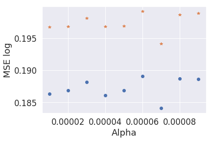

```python
alpha = np.arange(0.00001,0.0001,0.00001)
train_scores = np.array([])
test_scores = np.array([])
for a in alpha:
    Huber_model = HuberRegressor(alpha=a)
    Huber_model.fit(X_train_cleaned_outliers,y_train_cleaned_outliers)
    Huber_pred_test = Huber_model.predict(X_test_cleaned_outliers)
    Huber_pred_train = Huber_model.predict(X_train_cleaned_outliers)
    train_scores = np.append(train_scores,score(y_train_cleaned_outliers,Huber_pred_train))
    test_scores = np.append(test_scores,score(y_test_cleaned_outliers,Huber_pred_test)) #Donne le score sur le test après avoir procédé à un fit

plt.plot(alpha, train_scores,'o', alpha, test_scores,'*')
plt.xlabel("Alpha")
plt.ylabel("MSE log")
plt.show()
```

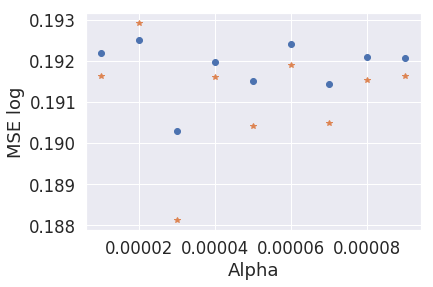

```python
alpha = np.arange(0.00001,0.0001,0.00001)
train_scores = np.array([])
test_scores = np.array([])
for a in alpha:
    Huber_model = HuberRegressor(alpha=a)
    Huber_model.fit(X_train_cleaned2_outliers,y_train_cleaned2_outliers)
    Huber_pred_test = Huber_model.predict(X_test_cleaned2_outliers)
    Huber_pred_train = Huber_model.predict(X_train_cleaned2_outliers)
    score(y_test_cleaned2_outliers.values,Huber_pred_test)
    train_scores = np.append(train_scores,score(y_train_cleaned2_outliers,Huber_pred_train))
    test_scores = np.append(test_scores,score(y_test_cleaned2_outliers,Huber_pred_test)) #Donne le score sur le test après avoir procédé à un fit

plt.plot(alpha, train_scores,'o', alpha, test_scores,'*')
plt.xlabel("Alpha")
plt.ylabel("MSE log")
plt.show()
```

Here we have tested with huber model the two way of cleaning datas

**Gradient boosting**

```python
df = pd.read_csv('Data/train_cleaned_outliersremoved.csv')
df.fillna(0,inplace=True)

features = list(df.columns)
del features[-1] # to avoid having saleprice in the training set ...
target = "SalePrice"

train,test = train_test_split(df,test_size=0.3)
X_train_cleaned_outliers = train[features]
y_train_cleaned_outliers = train[target]
X_test_cleaned_outliers = test[features]
y_test_cleaned_outliers = test[target]
```

As stated above we now use this to train and test our model.

```python
import scipy.stats
from sklearn.model_selection import ParameterSampler

hyperparameters = {

    'learning_rate': scipy.stats.uniform(0.0001,1),
    'n_estimators' : scipy.stats.randint(10, 1000),
    'max_depth': scipy.stats.randint(1, 10)
    }

parameter_grid = list(ParameterSampler(hyperparameters,n_iter=15))

resultsDF = pd.DataFrame(columns=['learning_rate', 'n_estimators','max_depth'])

for parameter_combination in parameter_grid:
    model = GradientBoostingRegressor(n_estimators=parameter_combination['n_estimators'], learning_rate=parameter_combination['learning_rate'], max_depth=parameter_combination['max_depth'])
    model=model.fit(X_train_cleaned_outliers,y_train_cleaned_outliers)
    pred = model.predict(X_test_cleaned_outliers.values)

    parameter_combination['score'] = score(y_test_cleaned_outliers,pred)
    resultsDF = resultsDF.append(parameter_combination, ignore_index=True)


resultsDF.sort_values(by='score')
```

|  | learning_rate | n_estimators | max_depth | score |
| --- | --- | --- | --- | --- |
| 13 | 0.083456 | 349.0 | 4.0 | 0.120285 |
| 9 | 0.067771 | 170.0 | 7.0 | 0.130892 |
| 12 | 0.041367 | 182.0 | 6.0 | 0.131202 |
| 3 | 0.413444 | 397.0 | 3.0 | 0.143006 |
| 6 | 0.734228 | 156.0 | 2.0 | 0.144659 |
| 7 | 0.517102 | 468.0 | 6.0 | 0.151910 |
| 8 | 0.791197 | 439.0 | 2.0 | 0.155440 |
| 0 | 0.436533 | 811.0 | 9.0 | 0.156933 |
| 11 | 0.616170 | 615.0 | 3.0 | 0.157884 |
| 1 | 0.469382 | 275.0 | 9.0 | 0.164272 |
| 4 | 0.843822 | 760.0 | 2.0 | 0.165537 |
| 10 | 0.662499 | 28.0 | 6.0 | 0.166081 |
| 5 | 0.622012 | 783.0 | 9.0 | 0.169613 |
| 14 | 0.930160 | 760.0 | 2.0 | 0.183010 |
| 2 | 0.920243 | 415.0 | 6.0 | 0.186899 |

**Random Forest**

```python
hyperparameters = {'n_estimators' : scipy.stats.randint(10, 100)}

parameter_grid = list(ParameterSampler(hyperparameters,n_iter=15))

resultsDF = pd.DataFrame(columns=['n_estimators'])

for parameter_combination in parameter_grid:

    model=RandomForestRegressor(n_estimators=parameter_combination['n_estimators'])
    model=model.fit(X_train_cleaned_outliers,y_train_cleaned_outliers)
    pred = model.predict(X_test_cleaned_outliers.values)

    parameter_combination['score'] = score(y_test_cleaned_outliers,pred)
    resultsDF = resultsDF.append(parameter_combination, ignore_index=True)


resultsDF.sort_values(by='score')
```

|  | n_estimators | score |
| --- | --- | --- |
| 8 | 76.0 | 0.131671 |
| 13 | 97.0 | 0.131994 |
| 0 | 66.0 | 0.133129 |
| 9 | 63.0 | 0.133223 |
| 2 | 99.0 | 0.133337 |
| 6 | 70.0 | 0.133617 |
| 4 | 71.0 | 0.133737 |
| 1 | 92.0 | 0.133785 |
| 12 | 90.0 | 0.134516 |
| 10 | 53.0 | 0.135679 |
| 7 | 24.0 | 0.136235 |
| 3 | 35.0 | 0.137793 |
| 14 | 10.0 | 0.140127 |
| 11 | 15.0 | 0.140164 |
| 5 | 10.0 | 0.140165 |

We've choen to work only on these two models because we lacked of time. For the submission we will use the best one.

## Submission

```python
df = pd.read_csv('Data/train_cleaned_outliersremoved.csv')
df.fillna(0, inplace=True)
features = list(df.columns)
del features[-1] # to avoid having saleprice in the training set ...
target = "SalePrice"

X_train = df[features]
y_train = df[target]

model = GradientBoostingRegressor(n_estimators=349, learning_rate=0.083456 , max_depth=4.0)   # best parameter according to the table abobve !
model=model.fit(X_train,y_train)
pred = model.predict(X_test_cleaned_outliers.values)

best_trained_model=model
```

```python
def compute_submission(dir_of_cleaned_test,best_trained_model):
    """This function compute and then write our submission in a csv file. It uses the fitted model provided
    Typical call: compute_submission('Data/test_cleaned2.csv',best_model)"""
    df = pd.read_csv(dir_of_cleaned_test)
    df2 = pd.read_csv('Data/test.csv')
    df.fillna(0,inplace=True)
    pred = best_trained_model.predict(df.values)
    ar = {'Id': df2.Id, 'SalePrice': pred}
    del df2
    submission = pd.DataFrame(data=ar)
    submission.to_csv("Data/submission.csv")
    print("submission written in Data/submission.csv")
    return submission

compute_submission('Data/test_cleaned.csv',best_trained_model)
```

```
submission written in Data/submission.csv
```

|  | Id | SalePrice |
| --- | --- | --- |
| 0 | 1201 | 96902.817848 |
| 1 | 1202 | 211238.969149 |
| 2 | 1203 | 123760.617627 |
| 3 | 1204 | 208325.065726 |
| 4 | 1205 | 153285.941527 |
| 5 | 1206 | 263493.583895 |
| 6 | 1207 | 125020.830512 |
| 7 | 1208 | 207040.900986 |
| 8 | 1209 | 143584.847821 |
| 9 | 1210 | 306150.919463 |
| 10 | 1211 | 193004.515561 |
| 11 | 1212 | 221078.071007 |
| 12 | 1213 | 99608.540660 |
| 13 | 1214 | 131574.225053 |
| 14 | 1215 | 128266.704099 |
| 15 | 1216 | 123244.118978 |
| 16 | 1217 | 125653.801988 |
| 17 | 1218 | 296288.106225 |
| 18 | 1219 | 87656.969133 |
| 19 | 1220 | 87300.008335 |
| 20 | 1221 | 120777.472728 |
| 21 | 1222 | 131547.064868 |
| 22 | 1223 | 141595.370220 |
| 23 | 1224 | 147855.859380 |
| 24 | 1225 | 184408.062201 |
| 25 | 1226 | 144700.098298 |
| 26 | 1227 | 214795.404324 |
| 27 | 1228 | 145479.552467 |
| 28 | 1229 | 378664.371838 |
| 29 | 1230 | 145759.070159 |
| ... | ... | ... |
| 230 | 1431 | 184995.921915 |
| 231 | 1432 | 139773.642605 |
| 232 | 1433 | 107055.090426 |
| 233 | 1434 | 184511.669122 |
| 234 | 1435 | 161573.928874 |
| 235 | 1436 | 163805.736659 |
| 236 | 1437 | 121598.153472 |
| 237 | 1438 | 366653.682051 |
| 238 | 1439 | 151077.458030 |
| 239 | 1440 | 185484.357928 |
| 240 | 1441 | 227676.566343 |
| 241 | 1442 | 144490.592397 |
| 242 | 1443 | 313817.831377 |
| 243 | 1444 | 96065.317430 |
| 244 | 1445 | 185122.817143 |
| 245 | 1446 | 133616.453513 |
| 246 | 1447 | 159571.604049 |
| 247 | 1448 | 274267.402382 |
| 248 | 1449 | 102811.845511 |
| 249 | 1450 | 98211.961324 |
| 250 | 1451 | 128860.585024 |
| 251 | 1452 | 245024.341122 |
| 252 | 1453 | 136826.783262 |
| 253 | 1454 | 145298.072809 |
| 254 | 1455 | 189785.638969 |
| 255 | 1456 | 175366.075485 |
| 256 | 1457 | 189320.728369 |
| 257 | 1458 | 263558.149563 |
| 258 | 1459 | 143653.223129 |
| 259 | 1460 | 149382.110812 |

260 rows × 2 columns

**Annex: Test of different trick**  
Train a model with the low corrrelated column removed

```python
X_train , X_test, Y_train, Y_test = train_test_split(train_selected,train_selected.SalePrice,test_size=0.20,random_state=123)

X_train = X_train.drop(['SalePrice'],axis = 1)
X_test = X_test.drop(['SalePrice'],axis = 1)
model=RandomForestRegressor()

model=model.fit(X_train,Y_train)
pred = model.predict(X_test)

print(score(Y_test,pred), "random forest")
```

```
0.16748309155533161 random forest
```

PCA

```python
# Test PCA
salePrice= pd.read_csv('Data/train_cleaned2.csv').SalePrice
X_train , X_test, Y_train, Y_test = train_test_split(train_PCA,salePrice,test_size=0.20)

from sklearn.ensemble import RandomForestRegressor
model=DecisionTreeRegressor()
model=model.fit(X_train,Y_train)
pred = model.predict(X_test)

print(score(Y_test,pred), "random forest")
```

```
0.21233192724334227 random forest
```

**Without any trick we reach 0.14**